# Econometria Financeira com o R – OLS e GLM

Análise de Dados Financeiros e Econômicos com o R

Marcelo S. Perlin

EA-UFRGS

12/11/2026

# Introduction

## Why Financial Econometrics?

> The modelling tools from financial econometrics allow the researcher to simulate, predict and test a particular hypothesis about the data.
- allow **correctly** testing different hypothesis about the real world
- models scale well! (likely to be usable for large data)
- can be very flexible towards a functional form of the data generating process

## Most popular models:

- **Linear models (OLS)**
- **Generalized linear models (GLM)**
- Panel data models (PDM)
- **Arima models (Integrated Autoregressive Moving Averages)**
- **Garch models (generalized autoregressive conditional heteroskedasticity)**
- Regime switching models

## Please read the references!

- Introductory econometrics for finance (Brooks 2014)
- Econometric analysis (Greene 2003)
- The econometrics of financial markets (Campbell et al. 1997)
- Time series analysis (Hamilton 1994)

# Linear Models

## Linear Models

> A linear model is, without a doubt, one of the most used econometric models in R and finance.

Why??

- simplicity
- quick estimation, even for HUGE amounts of data
- easy to interpret and process out of sample data

A linear model with *N* explanatory variables can be represented as follows:

$$y _t = \alpha + \beta _1 x_{1,t} + \beta _2 x_{2,t} + ... + \beta _N x_{N,t} + \epsilon _t$$

$y_t$ – dependent (or response) variable

$x_{i,t}$ – independent (or explanatory) variables.

$\beta _i$ – coefficients to be estimated

$\epsilon _t$ – Residual from linear equation

## Simulating a Linear Model

Consider the following equation:

$$y _t = 0.5 + 2 x_{t} + \epsilon _t$$

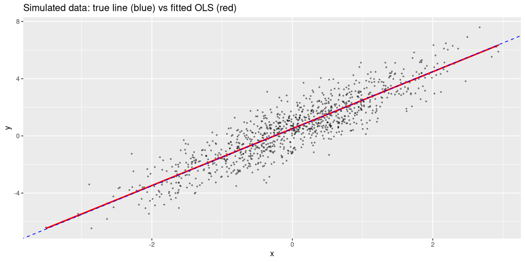

```r
set.seed(50)

# number of obs
nT <- 1000

# set x as Normal (0, 1)
x <- rnorm(nT)

# set coefficients
my_alpha <- 0.5
my_beta <- 2

# build y
y <- my_alpha + my_beta*x + rnorm(nT)

library(ggplot2)

# set temp df
temp.df <- dplyr::tibble(x, y)

# plot it
p <- ggplot(temp.df, aes(x = x, y = y)) +
  geom_point(size = 0.5, alpha = 0.4) +
  geom_smooth(method = "lm", se = FALSE, color = "red") +
  geom_abline(intercept = my_alpha, slope = my_beta,
              color = "blue", linetype = "dashed") +
  labs(x = "x", y = "y",
       title = "Simulated data: true line (blue) vs fitted OLS (red)")

print(p)
```

## Estimating a Linear Model

In R, the main function for estimating a linear model is `lm`. Let’s use it to estimate a model from the previous simulated data.

```r
# set df
df_reg <- dplyr::tibble(x, y)

# estimate linear model
my_lm <- lm(data = df_reg, formula = y ~ x)

print(my_lm)
```

```
Call:
lm(formula = y ~ x, data = df_reg)

Coefficients:
(Intercept)            x
     0.5083       1.9891
```

```r
library(broom)

# tidy table of coefficients with confidence intervals
tidy(my_lm, conf.int = TRUE)
```

```
# A tibble: 2 × 7
  term        estimate std.error statistic  p.value conf.low conf.high
  <chr>          <dbl>     <dbl>     <dbl>    <dbl>    <dbl>     <dbl>
1 (Intercept)    0.508    0.0311      16.4 1.74e-53    0.447     0.569
2 x              1.99     0.0303      65.6 0           1.93      2.05
```

more information about the previously estimated can be found with `summary`:

```r
print(summary(my_lm))
```

```
Call:
lm(formula = y ~ x, data = df_reg)

Residuals:
    Min      1Q  Median      3Q     Max
-3.0444 -0.6906 -0.0244  0.6807  3.2892

Coefficients:
            Estimate Std. Error t value Pr(>|t|)
(Intercept)  0.50830    0.03107   16.36   <2e-16 ***
x            1.98906    0.03031   65.61   <2e-16 ***
---
Signif. codes:  0 '***' 0.001 '**' 0.01 '*' 0.05 '.' 0.1 ' ' 1

Residual standard error: 0.9824 on 998 degrees of freedom
Multiple R-squared:  0.8118,    Adjusted R-squared:  0.8116
F-statistic:  4305 on 1 and 998 DF,  p-value: < 2.2e-16
```

## Reporting a single Linear Model

The typical model table can be constructed in R with `texreg` or `modelsummary`:

```r
library(texreg)

htmlreg(my_lm,
        include.rownames = FALSE,
        caption = "Simulated linear model")
```

Simulated linear model

|  | Model 1 |
| --- | --- |
| (Intercept) | 0.51*** |
|  | (0.03) |
| x | 1.99*** |
|  | (0.03) |
| R<sup>2</sup> | 0.81 |
| Adj. R<sup>2</sup> | 0.81 |
| Num. obs. | 1000 |

***p < 0.001; **p < 0.01; *p < 0.05

## Reporting many models

```r
library(texreg)

# nested models: does the extra flexibility improve the fit?
model_1 <- lm(data = df_reg, formula = y ~ x)
model_2 <- lm(data = df_reg, formula = y ~ x + I(x^2))
model_3 <- lm(data = df_reg, formula = y ~ x + I(x^2) + I(x^3))

htmlreg(l = list(model_1, model_2, model_3),
        custom.model.names = c("Linear", "Quadratic", "Cubic"),
        include.rownames = FALSE)
```

Statistical models

|  | Linear | Quadratic | Cubic |
| --- | --- | --- | --- |
| (Intercept) | 0.51*** | 0.50*** | 0.50*** |
|  | (0.03) | (0.04) | (0.04) |
| x | 1.99*** | 1.99*** | 1.97*** |
|  | (0.03) | (0.03) | (0.05) |
| x^2 |  | 0.01 | 0.01 |
|  |  | (0.02) | (0.02) |
| x^3 |  |  | 0.01 |
|  |  |  | (0.01) |
| R<sup>2</sup> | 0.81 | 0.81 | 0.81 |
| Adj. R<sup>2</sup> | 0.81 | 0.81 | 0.81 |
| Num. obs. | 1000 | 1000 | 1000 |

***p < 0.001; **p < 0.01; *p < 0.05

## A real world example

> The table is from published paper titled “The Academic Inbreeding Controversy: Analysis and Evidence from Brazil”, published in [Journal of Informetrics](https://doi.org/10.1016/j.joi.2022.101287)

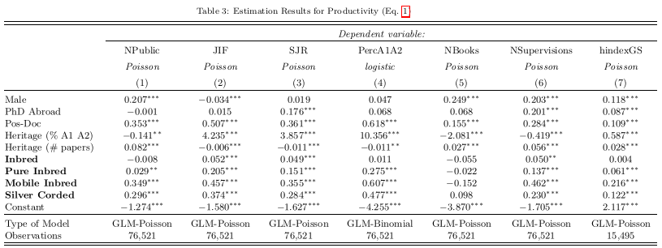

## Another real world example

> The table is from a **working paper** titled “The Academia Downturn: the Impact of COVID-19 in the Brazilian Academic Output”

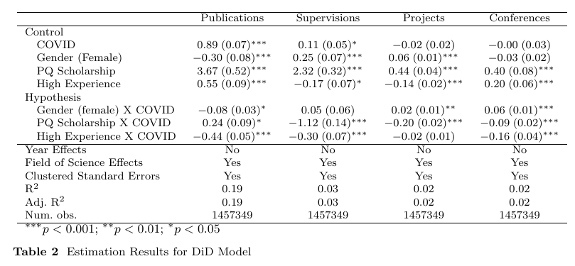

# Statistical Inference in Linear Models

> After estimating a model with function `lm`, the next step is to test some hypothesis about the coefficients.
- F-test: verifies the most basic condition for a model to justify its existence – it tests the assumption that all coefficients, excluding the intercept, are equal to zero.
- T-tests: tests the null hypothesis that individual coefficients (betas) are equal to zero.
- Adjusted R^2: R^2 penalized by the number of parameters, so it does not automatically increase when irrelevant variables are added.

## The F-test in `summary()`

When function `summary` is applied to a `lm` output, the F-test is provided by default in the last line of the text output. The null hypothesis of the test is that all slopes are equal to zero. Let’s try it:

```r
nT <- 100
df <- data.frame(y = runif(nT),
                 x1 = runif(nT),
                 x2 = runif(nT))

my_lm <- lm(data = df,
            formula = y ~ x1 + x2)

print(summary(my_lm))
```

```
Call:
lm(formula = y ~ x1 + x2, data = df)

Residuals:
     Min       1Q   Median       3Q      Max
-0.51446 -0.26408 -0.01434  0.27508  0.46685

Coefficients:
              Estimate Std. Error t value Pr(>|t|)
(Intercept)  0.5336338  0.0796171   6.703 1.36e-09 ***
x1          -0.0431787  0.1088555  -0.397    0.692
x2          -0.0003169  0.1136217  -0.003    0.998
---
Signif. codes:  0 '***' 0.001 '**' 0.01 '*' 0.05 '.' 0.1 ' ' 1

Residual standard error: 0.3015 on 97 degrees of freedom
Multiple R-squared:  0.001626,  Adjusted R-squared:  -0.01896
F-statistic: 0.07899 on 2 and 97 DF,  p-value: 0.9241
```

## Alternative hypothesis in linear regressions

> While T-test calculate the p-values associated with the event of the individual coefficient being equal to zero, we can also design other tests using a [Wald Test](https://en.wikipedia.org/wiki/Wald_test), such as a particular parameter being equal to a value

As a simple example, let’s test a linear hypothesis for a simulated model. Here, we will create artificial data and test the formal hypothesis that the estimated coefficients are equal to the actual values provided in the simulation.

```r
set.seed(10)

# number of time periods
nT <- 1000

# set parameters
intercept <- 0.5
beta <- 1.5

# simulate
x <- rnorm(nT)
y <- intercept + beta*x + rnorm(nT)

# set df
df <- data.frame(y, x)

# estimate model
my_lm <- lm(data = df,
            formula = y ~ x )
```

- After the estimation of the model, we use function `LinearHypothesis` from package `car` (Fox and Weisberg 2019) to implement our formal test.
- The tested hypotheses are represented using a matrix operation. With this matrix operation, we test the joint hypothesis that the intercept is equal to 0.5 and the slope is equivalent to 1.5.

$$\underbrace{\begin{bmatrix}
1 & 0 \\
0 & 1
\end{bmatrix}}_{hypothesis.matrix}\begin{bmatrix}
\alpha \\
\beta
\end{bmatrix} = \underbrace{\begin{bmatrix}
0.5 \\
1.5
\end{bmatrix} }_{rhs}$$

The actual R code that implements the test is given next.

```r
library(car)

# set test matrix
test_matrix <- matrix(c(intercept,  # alpha test value
                        beta))  # beta test value

# hypothesis matrix
hyp_mat <- matrix(c(1,0,
                    0,1),nrow = 2)

# do test
my_waldtest <- linearHypothesis(my_lm,
                                hypothesis.matrix = hyp_mat,
                                rhs = test_matrix)

# print result
print(my_waldtest)
```

```
Linear hypothesis test:
(Intercept) = 0.5
x = 1.5

Model 1: restricted model
Model 2: y ~ x

  Res.Df    RSS Df Sum of Sq      F Pr(>F)
1   1000 1089.1
2    998 1086.8  2    2.3766 1.0912 0.3362
```

As we can see, the test fails to reject the null hypothesis. This means our simulation worked, and the parameters are correctly estimated as expected.

## Testing OLS assumptions

> Another family of tests commonly applied to linear models is related to its assumptions. Every linear model estimated by OLS assumes:
1. linearity in the parameters,
2. independence of the errors,
3. homoscedasticity (constant variance),
4. no perfect multicollinearity,
5. errors approximately Normal (mainly for small-sample inference).
- If these assumptions are not true, the model may be inefficient or biased, meaning some modification or use of robust estimates is required.

## Visual diagnostics

> Formal tests are useful, but plots often reveal the problem faster.

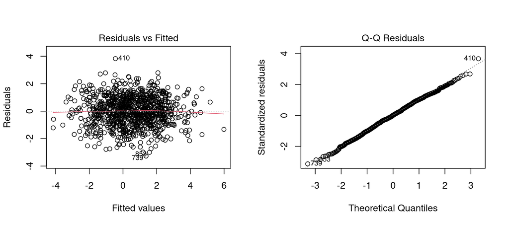

```r
par(mfrow = c(1, 2))
plot(my_lm, which = 1:2)
```

- **Residuals vs fitted**: a funnel shape suggests heteroscedasticity.
- **Normal Q-Q**: points far from the straight line suggest non-Normal errors.

## R packages for testing OLS assumptions

- package `lmtest` (Hothorn et al. 2022) tests for independence with the Breusch-Godfrey and Durbin-Watson tests.
- The Shapiro-Wilk test for normality is available in package `stats`.

```r
library(lmtest)

# Breusch-Godfrey test - Serial correlation
# Null hypothesis: no serial correlation in residuals
print(bgtest(my_lm, order = 5))

# Breusch-Pagan test - Non-constant variance
# Null hypothesis: homoscedasticity
print(ncvTest(my_lm))

# Durbin-Watson test - Serial correlation
# Null hypothesis: no serial correlation in residuals
print(dwtest(my_lm))

# Shapiro-Wilk test - Normality
# Null hypothesis: data is normally distributed
print(shapiro.test(my_lm$residuals))
```

```
    Breusch-Godfrey test for serial correlation of order up to 5

data:  my_lm
LM test = 4.2628, df = 5, p-value = 0.5122

Non-constant Variance Score Test
Variance formula: ~ fitted.values
Chisquare = 1.54328, Df = 1, p = 0.21413

    Durbin-Watson test

data:  my_lm
DW = 2.092, p-value = 0.9271
alternative hypothesis: true autocorrelation is greater than 0


    Shapiro-Wilk normality test

data:  my_lm$residuals
W = 0.99803, p-value = 0.2964
```

As expected, the model with artificial data passed all tests.

`dwtest()` assumes the residuals are in time order. Here the data is i.i.d., so treat this result as illustrative; we will use the test properly with time series.

## Robust standard errors

> If heteroscedasticity is present, the OLS point estimates are still unbiased, but the classical standard errors are wrong. A simple fix is to use heteroscedasticity-robust standard errors.

```r
set.seed(123)

n <- 500
x <- runif(n, 1, 10)
y <- 1 + 2*x + rnorm(n, sd = x)   # variance grows with x
df_het <- tibble::tibble(x, y)
lm_het <- lm(y ~ x, data = df_het)

library(sandwich)
library(lmtest)

# classical standard errors
print(coeftest(lm_het))
```

```
t test of coefficients:

            Estimate Std. Error t value Pr(>|t|)
(Intercept)  0.71554    0.63851  1.1206    0.263
x            2.07969    0.10594 19.6303   <2e-16 ***
---
Signif. codes:  0 '***' 0.001 '**' 0.01 '*' 0.05 '.' 0.1 ' ' 1
```

```r
# heteroscedasticity-robust standard errors (HC1)
print(coeftest(lm_het, vcov = vcovHC(lm_het, type = "HC1")))
```

```
t test of coefficients:

            Estimate Std. Error t value Pr(>|t|)
(Intercept)  0.71554    0.49563  1.4437   0.1494
x            2.07969    0.11804 17.6180   <2e-16 ***
---
Signif. codes:  0 '***' 0.001 '**' 0.01 '*' 0.05 '.' 0.1 ' ' 1
```

- The coefficients are identical; only the standard errors, t-statistics and p-values change.
- The robust version is usually the safer default when the variance of the errors is not constant.

## Global validation

> Package `gvlma` (Pena and Slate 2019) provides a top level function that can execute all sorts of tests in linear models, including the ones described before. The main advantage is that it outputs all tests in a single function call.

```r
library(gvlma)

# global validation of model
gvmodel <- gvlma(my_lm)

# print result
summary(gvmodel)
```

```
Call:
lm(formula = y ~ x, data = df)

Residuals:
    Min      1Q  Median      3Q     Max
-3.2703 -0.6898  0.0063  0.7346  3.8266

Coefficients:
            Estimate Std. Error t value Pr(>|t|)
(Intercept)  0.51510    0.03300   15.61   <2e-16 ***
x            1.54658    0.03329   46.46   <2e-16 ***
---
Signif. codes:  0 '***' 0.001 '**' 0.01 '*' 0.05 '.' 0.1 ' ' 1

Residual standard error: 1.044 on 998 degrees of freedom
Multiple R-squared:  0.6838,    Adjusted R-squared:  0.6835
F-statistic:  2159 on 1 and 998 DF,  p-value: < 2.2e-16


ASSESSMENT OF THE LINEAR MODEL ASSUMPTIONS
USING THE GLOBAL TEST ON 4 DEGREES-OF-FREEDOM:
Level of Significance =  0.05

Call:
 gvlma(x = my_lm)

                    Value p-value                Decision
Global Stat        3.6404  0.4569 Assumptions acceptable.
Skewness           1.7814  0.1820 Assumptions acceptable.
Kurtosis           0.1738  0.6767 Assumptions acceptable.
Link Function      0.6628  0.4156 Assumptions acceptable.
Heteroscedasticity 1.0224  0.3119 Assumptions acceptable.
```

# Generalized Linear Models (GLM)

## Introduction

> The generalized linear model (GLM) is a flexible alternative to a linear model. It allows the user to change the distribution of the response and the link function, which specifies how the expected response relates to the linear predictor.
- GLM is the right choice when the response is not continuous and unbounded: binary (`binomial`), counts (`poisson`), or positive continuous (`Gamma`).
- Applications of GLM in finance are mostly in credit models, which are used to predict the likelihood of an individual or company to default on its debt.

## Specification

We can write a general univariate GLM as:

$$E \left( y _t \right) = g \left(\alpha + \sum ^N _{i=1} \beta _i x_{i,t} \right)$$

Function *g()* can take many shapes. For example, if we are modelling a binary variable, we can use *g()* as the *logit* function:

$$g(x) = \frac{\exp(x)}{1+\exp(x)}$$

- function *g()* ensures any value of *x* will result in a number between 0 and 1.

## Why not just use OLS?

> With a binary response, OLS can produce predicted values below 0 or above 1, and the constant-variance assumption is violated.

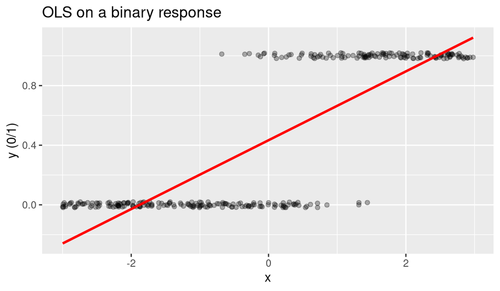

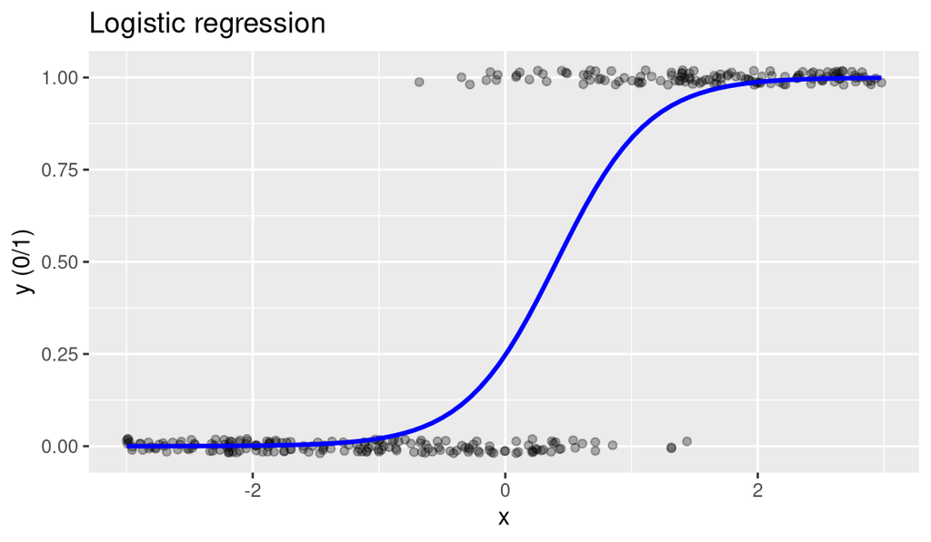

```r
set.seed(42)
n <- 300
x <- runif(n, -3, 3)
p <- plogis(-1 + 3*x)
y <- rbinom(n, 1, p)
df_bin <- tibble::tibble(x, y)

p_ols <- ggplot(df_bin, aes(x, y)) +
  geom_jitter(height = 0.02, alpha = 0.3) +
  geom_smooth(method = "lm", se = FALSE, color = "red") +
  labs(title = "OLS on a binary response", y = "y (0/1)")

p_glm <- ggplot(df_bin, aes(x, y)) +
  geom_jitter(height = 0.02, alpha = 0.3) +
  geom_smooth(method = "glm", method.args = list(family = binomial),
              se = FALSE, color = "blue") +
  labs(title = "Logistic regression", y = "y (0/1)")

print(p_ols)
print(p_glm)
```

- The OLS line is a straight line and can leave the [0, 1] interval.
- The logistic curve respects the natural bounds of a probability.

## Simulating a GLM Model

As an example, let’s simulate the following GLM model, where the response vector is a Bernoulli variable that takes value 1 with probability $p_t$. The probabilities are calculated from the non-linear transformation of $x_t$.

$$p _t = \frac{\exp(2+5x_t)}{1+\exp(2+5x_t)}$$

In R, we use the following code to build the response vector.

```r
set.seed(15)

# set number of obs
n_T <- 500

# set x
x <- rnorm(n_T)

my_alpha <- 2
my_beta <- 5

# set probabilities
z <- my_alpha + my_beta*x
p <- exp(z)/(1+exp(z))

# set response variable
y <- rbinom(n = n_T,
           size = 1,
           prob = p)
```

## The simulated data

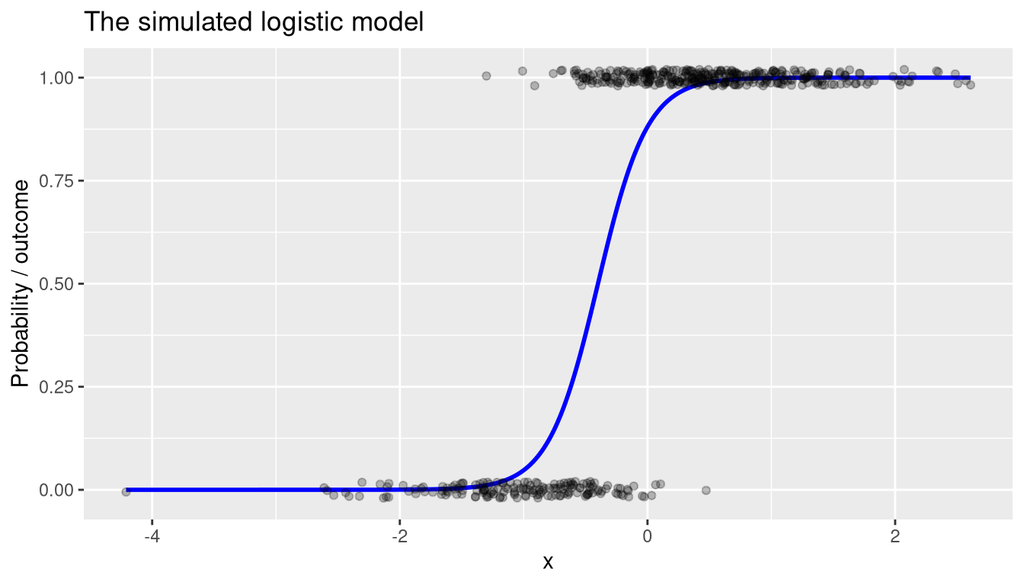

```r
sim_df <- tibble::tibble(x, p, y)

ggplot(sim_df, aes(x = x, y = p)) +
  geom_line(color = "blue", linewidth = 1) +
  geom_jitter(aes(y = y), height = 0.02, alpha = 0.25) +
  labs(x = "x", y = "Probability / outcome",
       title = "The simulated logistic model")
```

- The blue curve is the true probability $p_t = \exp(2 + 5x_t) / (1 + \exp(2 + 5x_t))$.
- The points are the realized binary outcomes $y_t \in \{0, 1\}$.

## Estimating a GLM Model

- In R, the estimation of GLM models is accomplished with function **stats::glm()**.

Let’s use the previously simulated data to estimate a *logit* model:

```r
# estimate GLM
df <- tibble::tibble(x, y)
my_family <- binomial(link = "logit")
my_glm <- glm(data = df,
              formula = y ~ x ,
              family = my_family)

# print it with summary
print(summary(my_glm))
```

```
Call:
glm(formula = y ~ x, family = my_family, data = df)

Coefficients:
            Estimate Std. Error z value Pr(>|z|)
(Intercept)   2.1488     0.2622   8.197 2.47e-16 ***
x             4.9050     0.5110   9.598  < 2e-16 ***
---
Signif. codes:  0 '***' 0.001 '**' 0.01 '*' 0.05 '.' 0.1 ' ' 1

(Dispersion parameter for binomial family taken to be 1)

    Null deviance: 634.18  on 499  degrees of freedom
Residual deviance: 214.14  on 498  degrees of freedom
AIC: 218.14

Number of Fisher Scoring iterations: 7
```

## An example with data

> Let’s use a credit card dataset from [Kaggle](https://www.kaggle.com/uciml/default-of-credit-card-clients-dataset)<sup>1</sup> to model credit risk.

```r
# read default data
my_f <- afedR3::data_path('CH11_UCI-Credit-Card.csv')
df_default <- readr::read_csv(my_f)

dplyr::glimpse(df_default)
```

```
Rows: 30,000
Columns: 25
$ ID                         <dbl> 1, 2, 3, 4, 5, 6, 7, 8, 9, 10, 11, 12, 13, …
$ LIMIT_BAL                  <dbl> 20000, 120000, 90000, 50000, 50000, 50000, …
$ SEX                        <dbl> 2, 2, 2, 2, 1, 1, 1, 2, 2, 1, 2, 2, 2, 1, 1…
$ EDUCATION                  <dbl> 2, 2, 2, 2, 2, 1, 1, 2, 3, 3, 3, 1, 2, 2, 1…
$ MARRIAGE                   <dbl> 1, 2, 2, 1, 1, 2, 2, 2, 1, 2, 2, 2, 2, 2, 2…
$ AGE                        <dbl> 24, 26, 34, 37, 57, 37, 29, 23, 28, 35, 34,…
$ PAY_0                      <dbl> 2, -1, 0, 0, -1, 0, 0, 0, 0, -2, 0, -1, -1,…
$ PAY_2                      <dbl> 2, 2, 0, 0, 0, 0, 0, -1, 0, -2, 0, -1, 0, 2…
$ PAY_3                      <dbl> -1, 0, 0, 0, -1, 0, 0, -1, 2, -2, 2, -1, -1…
$ PAY_4                      <dbl> -1, 0, 0, 0, 0, 0, 0, 0, 0, -2, 0, -1, -1, …
$ PAY_5                      <dbl> -2, 0, 0, 0, 0, 0, 0, 0, 0, -1, 0, -1, -1, …
$ PAY_6                      <dbl> -2, 2, 0, 0, 0, 0, 0, -1, 0, -1, -1, 2, -1,…
$ BILL_AMT1                  <dbl> 3913, 2682, 29239, 46990, 8617, 64400, 3679…
$ BILL_AMT2                  <dbl> 3102, 1725, 14027, 48233, 5670, 57069, 4120…
$ BILL_AMT3                  <dbl> 689, 2682, 13559, 49291, 35835, 57608, 4450…
$ BILL_AMT4                  <dbl> 0, 3272, 14331, 28314, 20940, 19394, 542653…
$ BILL_AMT5                  <dbl> 0, 3455, 14948, 28959, 19146, 19619, 483003…
$ BILL_AMT6                  <dbl> 0, 3261, 15549, 29547, 19131, 20024, 473944…
$ PAY_AMT1                   <dbl> 0, 0, 1518, 2000, 2000, 2500, 55000, 380, 3…
$ PAY_AMT2                   <dbl> 689, 1000, 1500, 2019, 36681, 1815, 40000, …
$ PAY_AMT3                   <dbl> 0, 1000, 1000, 1200, 10000, 657, 38000, 0, …
$ PAY_AMT4                   <dbl> 0, 1000, 1000, 1100, 9000, 1000, 20239, 581…
$ PAY_AMT5                   <dbl> 0, 0, 1000, 1069, 689, 1000, 13750, 1687, 1…
$ PAY_AMT6                   <dbl> 0, 2000, 5000, 1000, 679, 800, 13770, 1542,…
$ default.payment.next.month <dbl> 1, 1, 0, 0, 0, 0, 0, 0, 0, 0, 0, 0, 0, 1, 0…
```

For now, let’s simplify the analysis and focus on four columns: sex, education, marriage and age. For that, we’ll also need to decode the values in some columns.

```r
library(dplyr)

# read credit card data
# source:
# www.kaggle.com/uciml/default-of-credit-card-clients-dataset
# COLUMNS: GENDER: (1 = male; 2 = female).
#          EDUCATION: 0 = unknown; 1 = graduate school;
#                     2 = university;
#                     3 = high school;
#                     4 = others;
#                     5, 6 = unknown.
#          MARRIAGE: 1 = married;
#                    2 = single;
#                    3 = others
df_default <- df_default |>
  mutate(default = (default.payment.next.month == 1),
         D_male_gender = (SEX == 1),
         age = AGE,
         educ = dplyr::recode(as.character(EDUCATION),
                              '0' = 'Unknown',
                              '1' = 'Grad',
                              '2' = 'University',
                              '3' = 'High School',
                              '4' = 'Others',
                              '5' = 'Unknown',
                              '6' = 'Unknown'),
         D_marriage = (MARRIAGE == 1)) |>
  select(default, D_male_gender, age, educ, D_marriage)

glimpse(df_default)
```

```
Rows: 30,000
Columns: 5
$ default       <lgl> TRUE, TRUE, FALSE, FALSE, FALSE, FALSE, FALSE, FALSE, FA…
$ D_male_gender <lgl> FALSE, FALSE, FALSE, FALSE, TRUE, TRUE, TRUE, FALSE, FAL…
$ age           <dbl> 24, 26, 34, 37, 57, 37, 29, 23, 28, 35, 34, 51, 41, 30, …
$ educ          <chr> "University", "University", "University", "University", …
$ D_marriage    <lgl> TRUE, FALSE, FALSE, TRUE, TRUE, FALSE, FALSE, FALSE, TRU…
```

> **Data caveat:** 14 observations have `EDUCATION = 0` and none of them defaulted. If left as a separate level, they become the reference category and cause complete separation (huge coefficients and standard errors). We recode `0` to `Unknown`.

Much better! Now we only have the columns of interest, with more appealing names and content. Let’s proceed to the estimation of the glm model.

```r
# estimate glm model
glm_credit <- glm(data=df_default,
                  formula = default ~ D_male_gender +  age +
                                      educ + D_marriage,
                  family = binomial(link = "logit"))

# show output
summary(glm_credit)
```

```
Call:
glm(formula = default ~ D_male_gender + age + educ + D_marriage,
    family = binomial(link = "logit"), data = df_default)

Coefficients:
                   Estimate Std. Error z value Pr(>|z|)
(Intercept)       -1.487666   0.060838 -24.453  < 2e-16 ***
D_male_genderTRUE  0.207892   0.028503   7.294 3.01e-13 ***
age               -0.002417   0.001736  -1.393 0.163731
educHigh School    0.331518   0.042230   7.850 4.15e-15 ***
educOthers        -1.370155   0.390129  -3.512 0.000445 ***
educUniversity     0.257734   0.031936   8.070 7.01e-16 ***
educUnknown       -1.081717   0.205611  -5.261 1.43e-07 ***
D_marriageTRUE     0.130592   0.031603   4.132 3.59e-05 ***
---
Signif. codes:  0 '***' 0.001 '**' 0.01 '*' 0.05 '.' 0.1 ' ' 1

(Dispersion parameter for binomial family taken to be 1)

    Null deviance: 31705  on 29999  degrees of freedom
Residual deviance: 31460  on 29992  degrees of freedom
AIC: 31476

Number of Fisher Scoring iterations: 5
```

[^1]: https://www.kaggle.com/uciml/default-of-credit-card-clients-dataset

## Odds ratios

> The coefficients of a logistic model are on the **log-odds** scale. Exponentiating them gives **odds ratios**, which are easier to interpret.

```r
library(broom)

tidy(glm_credit, exponentiate = TRUE, conf.int = TRUE) |>
  dplyr::select(term, estimate, conf.low, conf.high, p.value) |>
  dplyr::mutate(dplyr::across(where(is.numeric), \(x) round(x, 3)))
```

```
# A tibble: 8 × 5
  term              estimate conf.low conf.high p.value
  <chr>                <dbl>    <dbl>     <dbl>   <dbl>
1 (Intercept)          0.226    0.2       0.254   0
2 D_male_genderTRUE    1.23     1.16      1.30    0
3 age                  0.998    0.994     1.00    0.164
4 educHigh School      1.39     1.28      1.51    0
5 educOthers           0.254    0.107     0.506   0
6 educUniversity       1.29     1.22      1.38    0
7 educUnknown          0.339    0.221     0.497   0
8 D_marriageTRUE       1.14     1.07      1.21    0
```

- An odds ratio above 1 means higher odds of default; below 1 means lower odds.
- For example, the odds ratio for `D_male_gender` is approximately 1.23.

## Goodness of fit

> The R^2 from OLS does not apply to a binary response. Useful alternatives are the McFadden pseudo-R^2, the AIC and the AUC.

```r
# McFadden pseudo-R2
pseudo_r2 <- 1 - as.numeric(logLik(glm_credit) / logLik(update(glm_credit, . ~ 1)))
print(pseudo_r2)
```

```
[1] 0.007726326
```

```r
# AIC (lower is better)
print(AIC(glm_credit))
```

```
[1] 31476.39
```

- McFadden pseudo-R^2 is usually much smaller than the OLS R^2; values between 0.2 and 0.4 already indicate a very good fit for a binary model.
- Here it is close to zero, consistent with the low AUC: demographics alone explain little about default.
- AIC is useful when comparing models estimated on the same data.

## From probabilities to decisions

> The model outputs a probability, not a yes/no answer. To classify a client, we must choose a threshold.

```r
# predicted probability of default
df_default$p_default <- predict(glm_credit, type = "response")

# classify using a 0.5 threshold
df_default$pred_default <- df_default$p_default > 0.5

# confusion matrix
pred_label <- factor(df_default$pred_default,
                     levels = c(TRUE, FALSE),
                     labels = c("Default", "No default"))
actual_label <- factor(df_default$default,
                       levels = c(TRUE, FALSE),
                       labels = c("Default", "No default"))

table(predicted = pred_label,
      actual = actual_label)
```

```
            actual
predicted    Default No default
  Default          0          0
  No default    6636      23364
```

- At the 0.5 threshold, this model classifies everyone as “no default”.
- The default rate is about 22.1%, so a model that always predicts “no default” would already be right most of the time.
- Accuracy alone is therefore misleading; we need measures such as sensitivity, specificity and AUC.

## ROC and AUC

```r
library(pROC)

my_roc <- pROC::roc(response = as.numeric(df_default$default),
                    predictor = df_default$p_default,
                    quiet = TRUE)

print(pROC::auc(my_roc))
```

```
Area under the curve: 0.5583
```

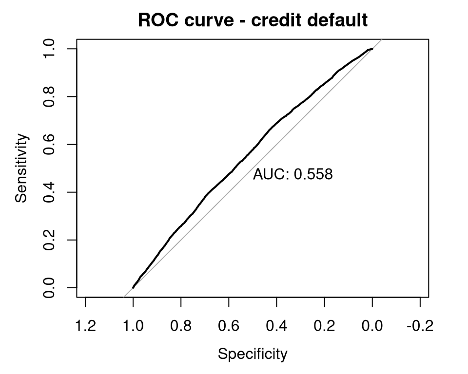

```r
plot(my_roc, print.auc = TRUE, main = "ROC curve - credit default")
```

- The ROC curve shows the trade-off between sensitivity and specificity for every possible threshold.
- AUC = 0.5 is a useless model; AUC = 1 is perfect. Here, AUC is about 0.558.
- This low AUC is expected: demographic variables alone are weak predictors. Real credit models use payment history, balances and other behavioural variables.

## Exercise 1 - Linear Model

1. Using package `yfR`, download adjusted price data for `^BVSP` and `GRND3.SA` from 2015 to 2023.
2. Estimate the beta of GRND3 from the following model:

$$R_t = \alpha + \beta R_{M,t} + \epsilon _t$$

3. Estimate a new market model with a dummy for negative returns:

$$R_t = \alpha + \beta _1 R_{M,t} + \beta _2 D_t R_{M,t} + \epsilon _t$$

Where $D_t = 1$ if $R_{M,t} <0$ and $D_t = 0$ otherwise

4. With the first model (without dummies), use package `car` to test the hypothesis that $\alpha=0$ and $\beta = 1$
5. Test the underlying assumptions of the previous linear model with package `gvlma`

## Exercise 2 - Linear Models

1. Using package `yfR`, download adjusted price data for PETR3, PETR4, GGBR3, GGBR4 from 2010 to 2018.
2. Using loops, estimate and save the beta of all stocks in a dataframe with two columns (ticker, beta):

$$R_t = \alpha + \beta R_{M,t} + \epsilon _t$$

3. Report the results of all models with `texreg::screenreg` in a single table

## Exercise 3 - GLM and credit risk

1. Re-estimate the credit model with `age`, `D_male_gender`, `educ` and `D_marriage`.
2. Report the odds ratios and interpret the effects of gender and marriage.
3. Compute the ROC curve and the AUC of the model.
4. Compare the AUC with a simpler model that uses only `D_male_gender` and `D_marriage`. Does education improve the ranking of clients?

## References

Brooks, Chris. 2014. *Introductory Econometrics for Finance*. Cambridge university press.

Campbell, John Y, Andrew Wen-Chuan Lo, Archie Craig MacKinlay, et al. 1997. *The Econometrics of Financial Markets*. Vol. 2. Princeton University press Princeton, NJ.

Fox, John, and Sanford Weisberg. 2019. *An R Companion to Applied Regression*. Third. Sage. https://www.john-fox.ca/Companion/.

Greene, William H. 2003. *Econometric Analysis*. Pearson Education India.

Hamilton, James Douglas. 1994. *Time Series Analysis*. Vol. 2. Princeton university press Princeton.

Hothorn, Torsten, Achim Zeileis, Richard W. Farebrother, and Clint Cummins. 2022. *Lmtest: Testing Linear Regression Models*. https://CRAN.R-project.org/package=lmtest.

Pena, Edsel A., and Elizabeth H. Slate. 2019. *Gvlma: Global Validation of Linear Models Assumptions*. https://CRAN.R-project.org/package=gvlma.